# Red Cross

fred dekker

2024-12-27

R Markdown

I used to compose this document a rmarkdown template from Medicines Sans Frontiers. This organisation made three outbreak reports and four survey templates. I used the cholera outbreak report as an example in this rmarkdown report. I made a selection of all the plots and tables to compose this report. Additional I used information The Epidemiologist R Handbook that also uses examples from the R4epis project

More detailed explanation about the templates, visit https://r4epis.netlify.app/training/walk-through/template_setup/ The package itself can be found on [GitHub issues page]https://r4epi.github.io/sitrep/

## Outbreak report

| Characteristic | Overall, N = 2501 | Female, N = 931 | Male, N = 671 | Missing, N = 901 |
| --- | --- | --- | --- | --- |
| Age group |  |  |  |  |
| 0-1 | 12 (4.8%) | 5 (5.4%) | 3 (4.5%) | 4 (4.4%) |
| 15-29 | 50 (20%) | 20 (22%) | 8 (12%) | 22 (24%) |
| 2-14 | 60 (24%) | 18 (19%) | 19 (28%) | 23 (26%) |
| 30-44 | 45 (18%) | 19 (20%) | 11 (16%) | 15 (17%) |
| 45+ | 83 (33%) | 31 (33%) | 26 (39%) | 26 (29%) |

1n (%)

## Age groups

There were 93 females and 67 males divided into five formulated age groups. These groups are an aggregation of the age variable in the dataset. It is a rough layout; typically, cohorts are smaller, for example, in five-year categories. However, such detailed cohorts are less comprehensible as a table or pyramid compared to using five groups. .

| Characteristic | Overall, N = 1601 | Female, N = 931 | Male, N = 671 |
| --- | --- | --- | --- |
| Age group |  |  |  |
| 0-1 | 8 (5.0%) | 5 (5.4%) | 3 (4.5%) |
| 15-29 | 28 (18%) | 20 (22%) | 8 (12%) |
| 2-14 | 37 (23%) | 18 (19%) | 19 (28%) |
| 30-44 | 30 (19%) | 19 (20%) | 11 (16%) |
| 45+ | 57 (36%) | 31 (33%) | 26 (39%) |

1n (%)

## Age pyramid

The age pyramid excludes individuals whose gender is missing. Additionally, the results are not weighted for the population. Therefore, this is the representation of the men and women registered in the database.

[figure not shown]

## Case Definition

There are three categories: confirmed, probable, and suspected. This distribution is applied to inpatients. In total, there are 166 inpatients and 84 outpatients.

|  | Case definition Confirmed | Case definition Probable | Case definition Suspected | Total |
| --- | --- | --- | --- | --- |
| Calendar Week |  |  |  |  |
| 2018 W03 | 1 (0.8%) | 0 (0%) | 0 (0%) | 1 (0.6%) |
| 2018 W04 | 2 (1.7%) | 0 (0%) | 0 (0%) | 2 (1.2%) |
| 2018 W05 | 2 (1.7%) | 0 (0%) | 0 (0%) | 2 (1.2%) |
| 2018 W06 | 5 (4.1%) | 0 (0%) | 2 (8.3%) | 7 (4.2%) |
| 2018 W07 | 6 (5.0%) | 2 (9.5%) | 0 (0%) | 8 (4.8%) |
| 2018 W08 | 1 (0.8%) | 0 (0%) | 2 (8.3%) | 3 (1.8%) |
| 2018 W09 | 6 (5.0%) | 1 (4.8%) | 2 (8.3%) | 9 (5.4%) |
| 2018 W10 | 13 (11%) | 3 (14%) | 3 (13%) | 19 (11%) |
| 2018 W11 | 17 (14%) | 2 (9.5%) | 0 (0%) | 19 (11%) |
| 2018 W12 | 11 (9.1%) | 1 (4.8%) | 1 (4.2%) | 13 (7.8%) |
| 2018 W13 | 12 (9.9%) | 1 (4.8%) | 4 (17%) | 17 (10%) |
| 2018 W14 | 8 (6.6%) | 1 (4.8%) | 2 (8.3%) | 11 (6.6%) |
| 2018 W15 | 15 (12%) | 2 (9.5%) | 5 (21%) | 22 (13%) |
| 2018 W16 | 10 (8.3%) | 3 (14%) | 1 (4.2%) | 14 (8.4%) |
| 2018 W17 | 12 (9.9%) | 5 (24%) | 2 (8.3%) | 19 (11%) |
| Total | 121 (100%) | 21 (100%) | 24 (100%) | 166 (100%) |

## Cases

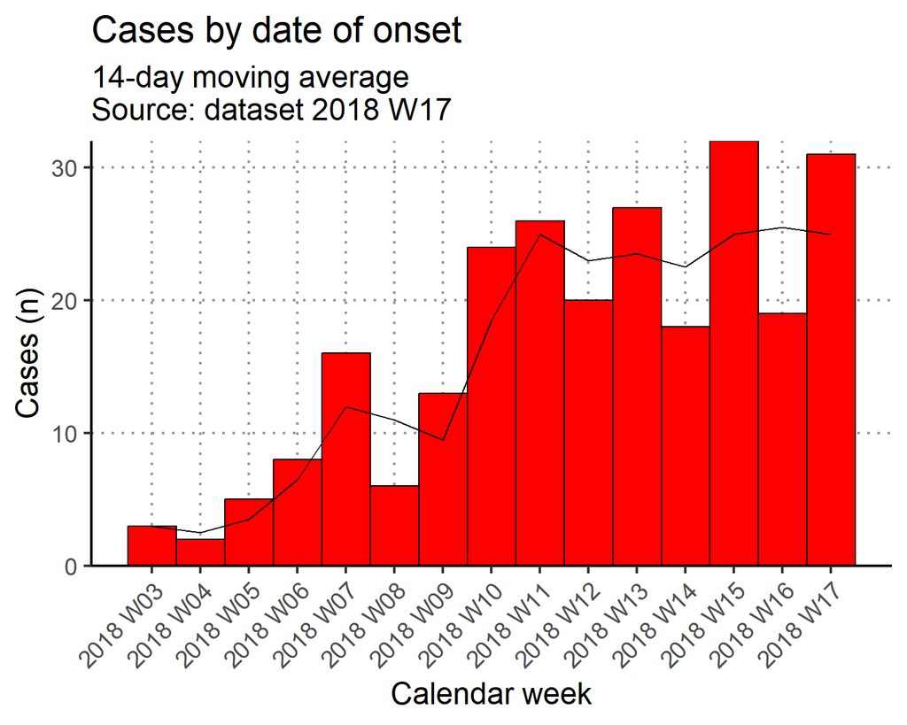

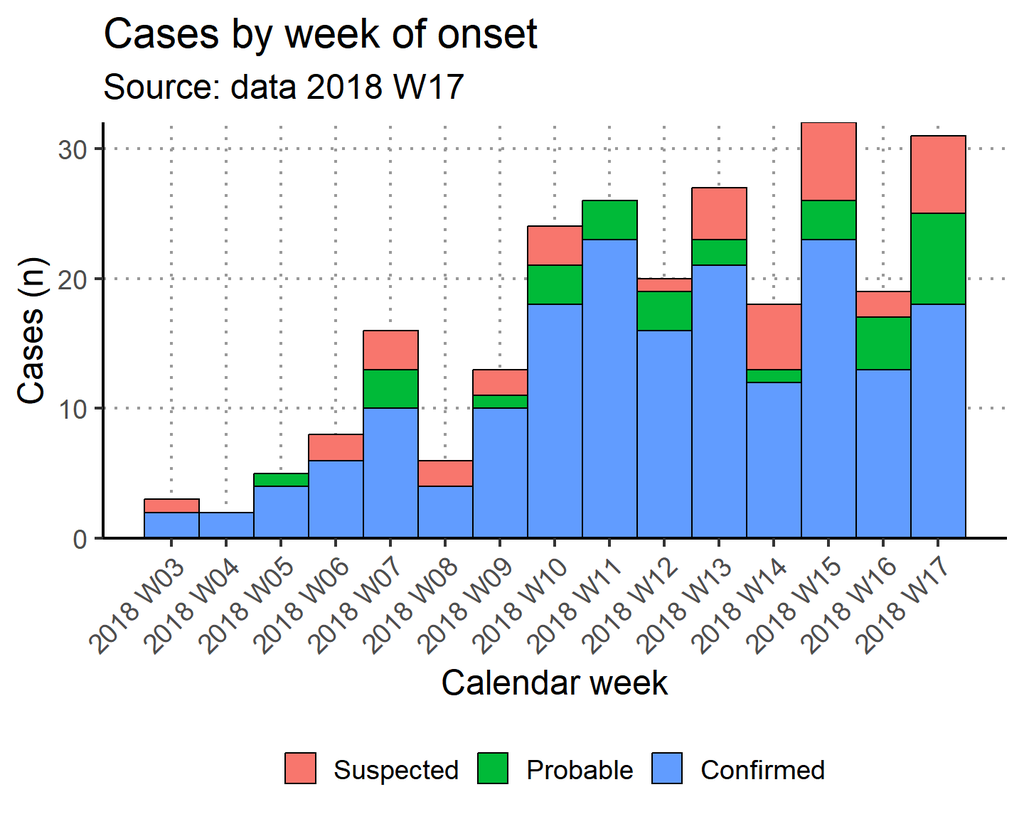

## Attack rate

The attack rate is the number of cases divided by the total population. In this database, suspected cases are also included. There were 12 cases in the first age group (0-1). Missing cases (gender) are also included. 12/340 * 10,000 implies an attack rate of 352 persons per 10,000 residents. A 95% confidence interval is calculated based on a binomial test. This test calculates the probability of success from the outcome of a series of success-failure experiments. For example, 12 cases in a population of 340.

a calculator for a binominal interval https://epitools.ausvet.com.au/ciproportion result x 10.000 or table / 10.000

| Characteristic | Cases | Population | AR (per 10,000) | 95%CI |
| --- | --- | --- | --- | --- |
| Age Group |  |  |  |  |
| 0-1 | 12 | 340 | 352.94 | (203.03-606.69) |
| 15-29 | 50 | 1,811 | 276.09 | (210.05-362.13) |
| 2-14 | 60 | 1,380 | 434.78 | (339.27-555.65) |
| 30-44 | 45 | 808 | 556.93 | (418.81-737.10) |
| 45+ | 83 | 661 | 1255.67 | (1024.50-1530.11) |

## Attack rate by region

The table shows the cases in the villages in the region. For the attack rate, the multiplier is 10,000. Additionally, the confidence interval is based on a binomial test.

| Region | Cases (n) | Population | AR (per 10,000) | 95%CI |
| --- | --- | --- | --- | --- |
| Village A | 64 | 1,105.0 | 579.2 | (456.16-732.84) |
| Village B | 52 | 870.0 | 597.7 | (458.69-775.42) |
| Village C | 67 | 1,775.0 | 377.5 | (298.32-476.57) |
| Village D | 67 | 1,250.0 | 536.0 | (424.26-675.09) |

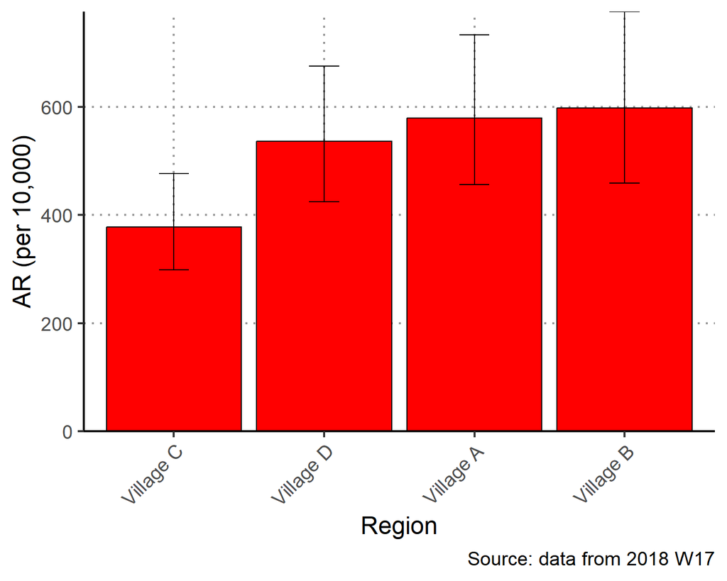

## Fatality Rate

The Case Fatality Rate (CFR) is not the same as the mortality rate. The CFR is the number of deaths from a disease divided by the number of confirmed cases of the disease. In this MSF report, they have chosen the number of inpatients as the denominator. The denominator is the number below the line in a fraction (e.g., 3/4). Inpatients are those who are receiving medical treatment in a hospital.

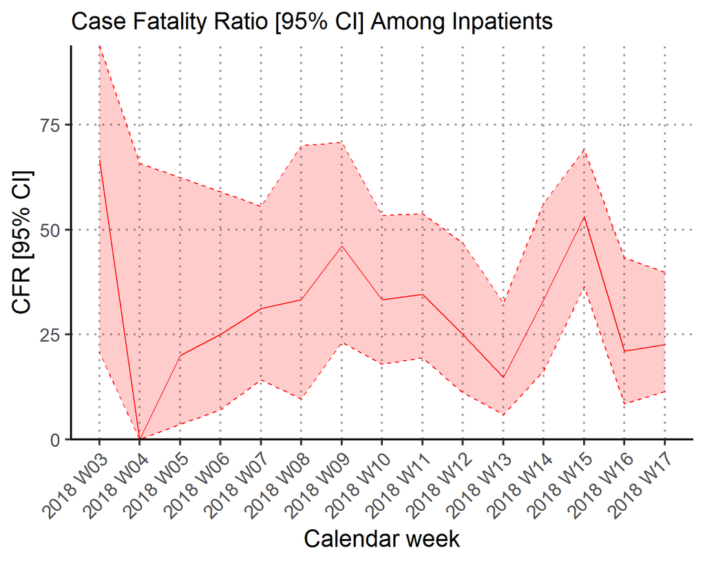

## Mortality rate

There are many ways to calculate mortality. The MSF template shows and calculates three different ways to express mortality in a figure. Three different denominators (numbers below the line in a fraction, e.g., 3/4) are used to judge the ratio figure.

The Epidemiologist R Handbook mentions and discusses several standard rates and how they can be compared with standard populations.

.

| Deaths | Population | Mortality (per 10,000) | 95%CI |
| --- | --- | --- | --- |
| 78 | 5,000.0 | 156.0 | (125.18-194.26) |

| Deaths | Person-days | Mortality (per 10,000/day) | 95%CI |
| --- | --- | --- | --- |
| 78 | 590,000.0 | 1.3 | (1.06-1.65) |

| Deaths | Population | Mortality (per 10,000/day) | 95%CI |
| --- | --- | --- | --- |
| 78 | 8,392.0 | 92.9 | (74.54-115.84) |

## Some details about the figures

In the first table, deaths are divided by the population: 78/5000 * 10,000. In the second table, the time between the first case and the last registered case was 118 days * population (5000). In the last table, the total sum of the individual observation days is the denominator. The template notes that this will give you an unreasonably high mortality rate.

.